# Weather Event and the impact on population

Abhishek Sinha

July 28, 2017

# Impact of weather events on population health and economy

## Synopsis

With the data provided by U.S. National Oceanic and Atmospheric Administration on storm, we have performed analysis on the impact of weather event on population health(fatalities and injuries) and economy.

Similarly, Hail has impacted the most on Crop Damages, which Tornado has biggest effect on Property Damages.

## Loading and processing the data

```r
if(!file.exists("StormData.csv.bz2"))
{
    download.file("https://d396qusza40orc.cloudfront.net/repdata%2Fdata%2FStormData.csv.bz2","StormData.csv.bz2")
}
storm.data <- read.csv("StormData.csv.bz2", header = T)
```

```r
storm.data <- storm.data[,c("EVTYPE","FATALITIES","INJURIES","PROPDMG","PROPDMGEXP","CROPDMG","CROPDMGEXP")]
```

### Function to replace units

Units (H, K, M and B) are defined in the two fields (PROPDMGEXP, CROPDMGEXP). It is important to convert them into numbers for comparision. E.g. H - 100, K - 1000, M - 1000000, B - 1000000000

```r
replace_units <- function(x)
{
        ifelse(is.na(x),return(1),
               ifelse(x=='K'|x=='k',return(1000),
                      ifelse(x=='H'|x=='h',return(100),
                             ifelse(x=='M'|x=='m',return(1000000),
                                    ifelse(x=='B'|x=='b',return(1000000000),1)
                             )
                      )
               )
        )
        return(1)
}
```

### Tidying up data

Update Crop Damage and Property damage appropriately.

```r
storm.data$PROPDMGEXP <- replace_units(storm.data$PROPDMGEXP)
storm.data$CROPDMGEXP <- replace_units(storm.data$CROPDMGEXP)
storm.data$PROPDMG <- storm.data$PROPDMG * storm.data$PROPDMGEXP
storm.data$CROPDMG <- storm.data$CROPDMG * storm.data$CROPDMGEXP
storm.data$PROPDMGEXP <- NULL
storm.data$CROPDMGEXP <- NULL

#Update column names of the dataframe
colnames(storm.data) <- c("EventType","Fatalities","Injuries","PropertyDamage","CropDamage")
```

## Events that are most harmful to population health

### Fatalities

Summarize the sum of fatalities by event type and look at top 10 events

```r
fatalitiest.eventtype <- aggregate(Fatalities ~ EventType, data = storm.data, FUN = sum)
top.event.fatalities <- head(fatalitiest.eventtype[order(-fatalitiest.eventtype$Fatalities),],10)
```

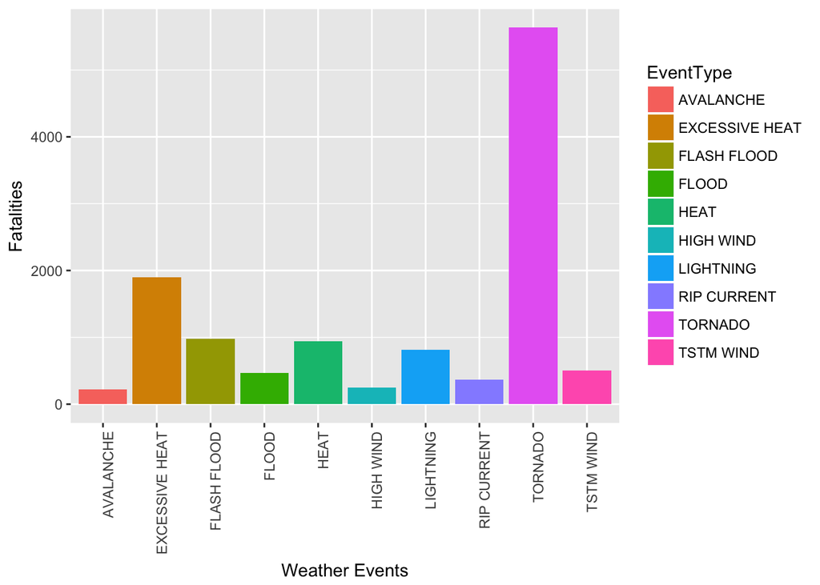

```r
ggplot(top.event.fatalities) + aes(x = EventType, y=Fatalities, fill=EventType) + geom_bar(stat="identity") +
    xlab("Weather Events") + ylab("Fatalities") + theme(axis.text.x = element_text(angle = 90, hjust = 1))
```

### Injuries

Summarize the sum of injuries by event type and look at top 10 events

```r
injuries.eventtype <- aggregate(Injuries ~ EventType, data = storm.data, FUN = sum)
top.event.injuries <- head(injuries.eventtype[order(-injuries.eventtype$Injuries),],10)
```

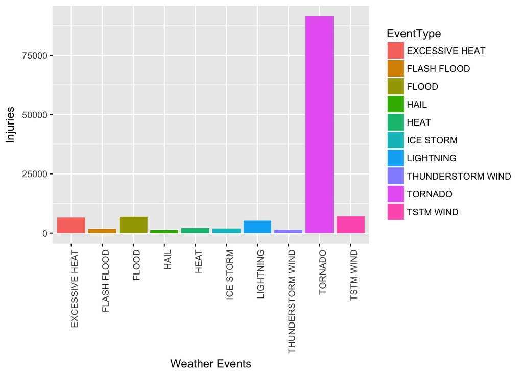

```r
ggplot(top.event.injuries) + aes(x = EventType, y=Injuries, fill=EventType) + geom_bar(stat="identity") +
    xlab("Weather Events") + ylab("Injuries") + theme(axis.text.x = element_text(angle = 90, hjust = 1))
```

## Events that had the greatest economic consequences

### Property Damage

Summarize the sum of property damage by event type and look at top 10 events

```r
property.damage.eventtype <- aggregate(PropertyDamage ~ EventType, data = storm.data, FUN = sum)
top.event.prop.damage <- head(property.damage.eventtype[order(-property.damage.eventtype$PropertyDamage),],10)
head(top.event.prop.damage, 10)
```

```
##              EventType PropertyDamage
## 834            TORNADO     3212258160
## 153        FLASH FLOOD     1420124590
## 856          TSTM WIND     1335965610
## 170              FLOOD      899938480
## 760  THUNDERSTORM WIND      876844170
## 244               HAIL      688693380
## 464          LIGHTNING      603351780
## 786 THUNDERSTORM WINDS      446293180
## 359          HIGH WIND      324731560
## 972       WINTER STORM      132720590
```

### Crop Damage

Summarize the sum of crop damage by event type and look at top 10 events

```r
crop.damage.eventtype <- aggregate(CropDamage ~ EventType, data = storm.data, FUN = sum)
top.event.crop.damage <- head(crop.damage.eventtype[order(-crop.damage.eventtype$CropDamage),],10)
head(top.event.crop.damage, 10)
```

```
##              EventType CropDamage
## 244               HAIL  579596280
## 153        FLASH FLOOD  179200460
## 170              FLOOD  168037880
## 856          TSTM WIND  109202600
## 834            TORNADO  100018520
## 760  THUNDERSTORM WIND   66791450
## 95             DROUGHT   33898620
## 786 THUNDERSTORM WINDS   18684930
## 359          HIGH WIND   17283210
## 290         HEAVY RAIN   11122800
```

### Overall Damage

```r
storm.data$CropPropertyDamage <- storm.data$CropDamage + storm.data$PropertyDamage
damage.eventtype <- aggregate(CropPropertyDamage ~ EventType, data = storm.data, FUN = sum)
top.event.damage <- head(damage.eventtype[order(-damage.eventtype$CropPropertyDamage),],10)
```

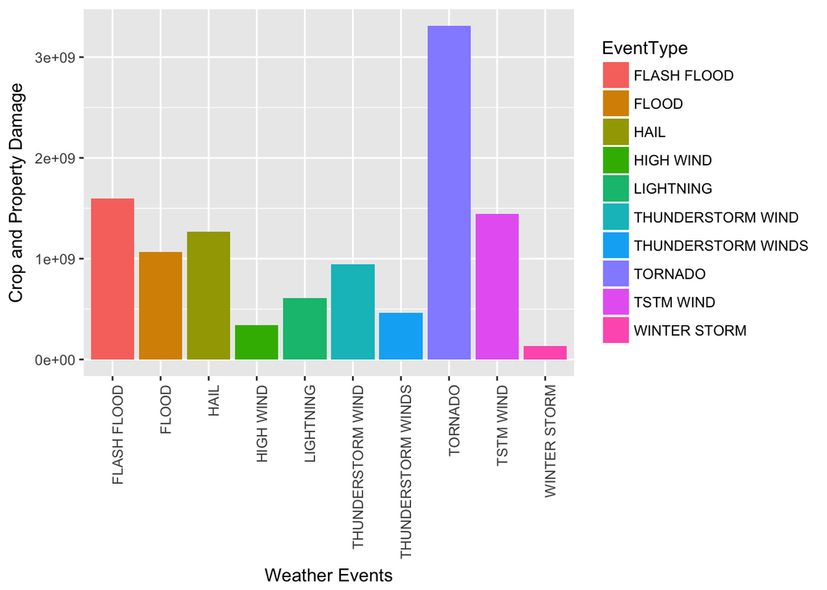

```r
ggplot(top.event.damage) + aes(x = EventType, y=CropPropertyDamage, fill=EventType) + geom_bar(stat="identity") +
    xlab("Weather Events") + ylab("Crop and Property Damage") + theme(axis.text.x = element_text(angle = 90, hjust = 1))
```

## Results

The final analysis suggests Tornado being the biggest impactful weather event impacting both health and economy. TSTM Wind, Flash Flood and Hail also has a high impact on economy.

Similarly, Tornado is the highes fatalities and has a similar impact on number of injuries.